# Chapter 6 — Comparing Two Groups (R companion)

R/tidyverse translation of *Understanding Data by Alan Garfinkel and Yina Guo

Adrian Soto-Mota, MD, PhD, FACP.

2026-04-24

# Orientation

Chapter 6 (book pp. 203–284) is the workhorse. It compares two groups using **simulation-based hypothesis tests** (Big Box and Re-centered Two-Box) and then reveals how and why the classical t-test is a special case of these. The book contains **one explicit Python snippet** in this chapter (§6.9 “What is a t-test?”, p. 272, reproduced in-place below). This companion implements both resampling procedures from scratch.

# §6.1–6.2 — Data and the effect size Δ_obs *(book pp. 204, 208)*

```r
# Control vs. Treatment T-cell counts (chapter example, reconstructed)
control   <- c(215, 189, 226, 201, 198, 210, 205, 223, 192, 208,
               218, 199, 212, 207, 195, 221, 203, 200, 214, 209)
treatment <- c(234, 219, 248, 252, 231, 245, 228, 240, 237, 255,
               225, 243, 250, 236, 229, 246, 233, 241, 253, 238)

df <- tibble(
  group = rep(c("Control", "Treatment"),
              c(length(control), length(treatment))),
  count = c(control, treatment)
)

# Effect size: difference in means (Δ_obs)
delta_obs <- mean(treatment) - mean(control)
delta_obs
```

```
## [1] 31.9
```

## Show the data first

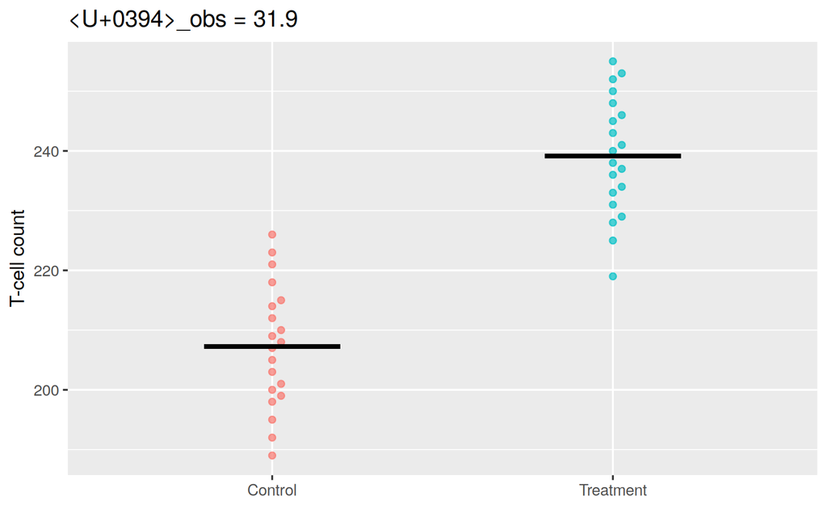

```r
ggplot(df, aes(group, count, color = group)) +
  geom_beeswarm(alpha = 0.7, cex = 2) +
  stat_summary(fun = mean, geom = "crossbar",
               width = 0.4, color = "black") +
  labs(title = sprintf("Δ_obs = %.1f", delta_obs),
       x = NULL, y = "T-cell count") +
  theme(legend.position = "none")
```

# §6.3 — The Big Box method *(book p. 210)*

**Idea:** Under the null, Control and Treatment come from the **same** population. Pool all observations into one “big box”, then repeatedly re-deal them into two groups of the original sizes. See how extreme Δ_obs is against that null distribution of Δ.

```r
big_box <- c(control, treatment)
n_A     <- length(control)
n_B     <- length(treatment)
n_sim   <- 10000

null_deltas <- numeric(n_sim)
for (i in seq_len(n_sim)) {
  shuffled         <- sample(big_box)                     # reshuffle all observations
  pseudo_A         <- shuffled[seq_len(n_A)]              # first n_A → pseudo-Control
  pseudo_B         <- shuffled[(n_A + 1):(n_A + n_B)]     # rest    → pseudo-Treatment
  null_deltas[i]   <- mean(pseudo_B) - mean(pseudo_A)     # pseudo-Δ
}

# Two-sided p-value
p_value <- mean(abs(null_deltas) >= abs(delta_obs))
p_value
```

```
## [1] 0
```

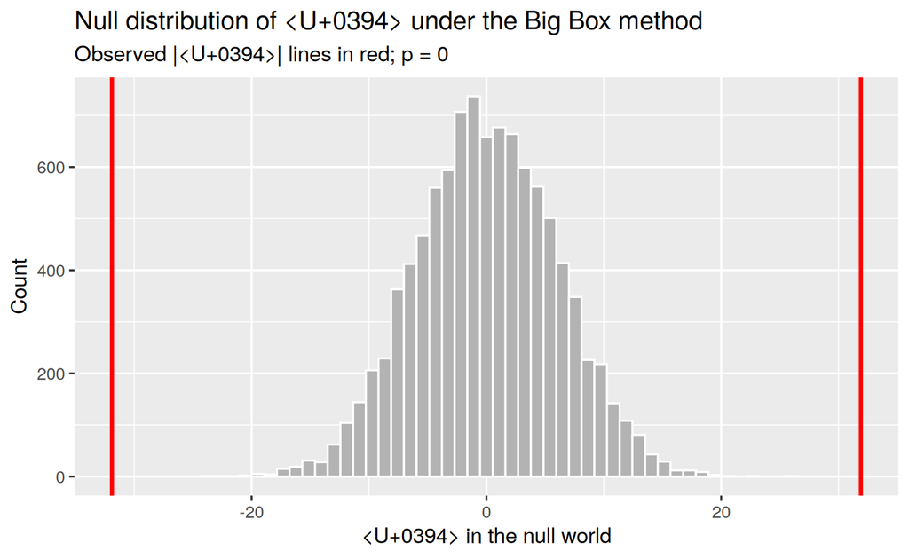

```r
tibble(delta = null_deltas) |>
  ggplot(aes(delta)) +
  geom_histogram(bins = 60, fill = "grey70", color = "white") +
  geom_vline(xintercept = c(-delta_obs, delta_obs),
             color = "red", linewidth = 1) +
  labs(title = "Null distribution of Δ under the Big Box method",
       subtitle = paste("Observed |Δ| lines in red; p =",
                        signif(p_value, 3)),
       x = "Δ in the null world", y = "Count")
```

# §6.3 — The Re-centered Two-Box method *(book p. 218)*

When the two groups have **very different variances** (chapter rule: > 2:1), the Big Box contaminates each group’s spread with the other’s. The fix is to **re-center** each group to the same mean, then resample *within* each box.

```r
# Re-center each group so both have mean 0
A_c <- control   - mean(control)
B_c <- treatment - mean(treatment)

null_deltas_2box <- numeric(n_sim)
for (i in seq_len(n_sim)) {
  pseudo_A <- sample(A_c, n_A, replace = TRUE)
  pseudo_B <- sample(B_c, n_B, replace = TRUE)
  null_deltas_2box[i] <- mean(pseudo_B) - mean(pseudo_A)
}

p_value_2box <- mean(abs(null_deltas_2box) >= abs(delta_obs))
p_value_2box
```

```
## [1] 0
```

For the T-cell example the two methods agree closely because the group variances are similar. For the chapter’s cancer-drug example (where variances differ strongly), they diverge.

# §6.4 — Confidence interval for Δ *(book p. 229)*

The CI is built by bootstrapping each group **separately** (not pooled).

```r
B <- 10000
boot_deltas <- numeric(B)
for (i in seq_len(B)) {
  A_star <- sample(control,   n_A, replace = TRUE)
  B_star <- sample(treatment, n_B, replace = TRUE)
  boot_deltas[i] <- mean(B_star) - mean(A_star)
}

ci_95 <- quantile(boot_deltas, c(0.025, 0.975))
ci_95
```

```
##  2.5% 97.5%
## 25.75 38.00
```

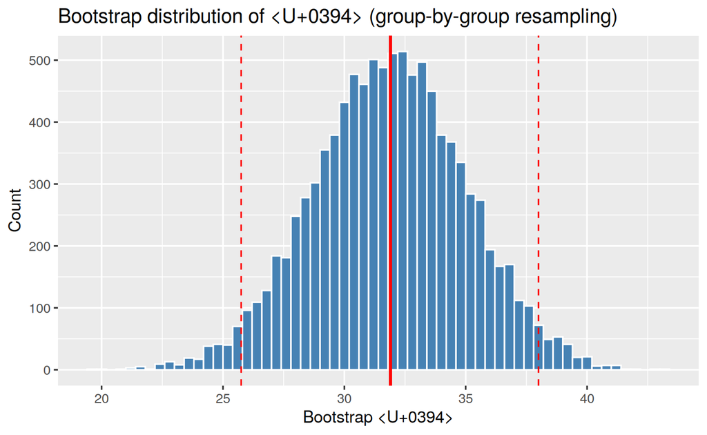

```r
tibble(delta = boot_deltas) |>
  ggplot(aes(delta)) +
  geom_histogram(bins = 60, fill = "steelblue", color = "white") +
  geom_vline(xintercept = delta_obs, color = "red", linewidth = 1) +
  geom_vline(xintercept = ci_95, color = "red", linetype = "dashed") +
  labs(title = "Bootstrap distribution of Δ (group-by-group resampling)",
       x = "Bootstrap Δ", y = "Count")
```

Since the CI excludes zero, this is consistent with p < 0.05 from the null test.

# §6.6 — Rank-based alternative *(book p. 242)*

If groups are clearly non-Normal, rank-transform first. The test statistic becomes the Wilcoxon-Mann-Whitney U.

```r
# Idiomatic R:
wilcox.test(treatment, control, exact = FALSE)
```

```
##
##  Wilcoxon rank sum test with continuity correction
##
## data:  treatment and control
## W = 396, p-value = 1.235e-07
## alternative hypothesis: true location shift is not equal to 0
```

```r
# Conceptual version: permutation test on rank sums
combined <- c(control, treatment)
r        <- rank(combined)
obs_rs   <- sum(r[(n_A + 1):(n_A + n_B)])   # rank sum of treatment

null_rs <- numeric(n_sim)
for (i in seq_len(n_sim)) {
  idx <- sample(seq_along(combined), n_B)
  null_rs[i] <- sum(r[idx])
}
mean(abs(null_rs - mean(null_rs)) >= abs(obs_rs - mean(null_rs)))
```

```
## [1] 0
```

# §6.7 — Paired study design *(book p. 248)*

**Swimsuit vs wetsuit:** the same swimmers each wear both, so the right analysis works on the **differences within pairs**.

```r
set.seed(7)
# 12 swimmers, each timed in swimsuit and wetsuit
swimsuit <- rnorm(12, mean = 60, sd = 3)
wetsuit  <- swimsuit - rnorm(12, mean = 3, sd = 0.5)  # wetsuit is reliably faster

paired_df <- tibble(
  swimmer  = 1:12,
  swimsuit = swimsuit,
  wetsuit  = wetsuit,
  diff     = swimsuit - wetsuit
)
paired_df
```

```
## # A tibble: 12 x 4
##    swimmer swimsuit wetsuit  diff
##      <int>    <dbl>   <dbl> <dbl>
##  1       1     66.9    62.7  4.14
##  2       2     56.4    53.2  3.16
##  3       3     57.9    54.0  3.95
##  4       4     58.8    55.5  3.23
##  5       5     57.1    54.5  2.55
##  6       6     57.2    54.3  2.85
##  7       7     62.2    59.2  3.00
##  8       8     59.6    56.2  3.49
##  9       9     60.5    57.0  3.42
## 10      10     66.6    63.2  3.35
## 11      11     61.1    57.4  3.65
## 12      12     68.2    65.8  2.31
```

## Wrong: independent-samples analysis ignores the pairing

```r
t.test(swimsuit, wetsuit)$p.value  # High p, large SE — swamped by swimmer-to-swimmer variability
```

```
## [1] 0.06546966
```

## Right: analyze the differences

```r
t.test(paired_df$diff)$p.value     # Much smaller p
```

```
## [1] 3.025432e-10
```

```r
# Bootstrap CI for the paired mean difference
B <- 10000
boot_md <- replicate(B, mean(sample(paired_df$diff,
                                    nrow(paired_df), replace = TRUE)))
quantile(boot_md, c(0.025, 0.975))
```

```
##     2.5%    97.5%
## 2.967547 3.553368
```

The paired analysis gains power by subtracting out between-swimmer variation.

# §6.8 — Effect size as a ratio *(book p. 262)*

For multiplicative data (e.g., gene expression), use the **ratio** of means, and work on the log scale so “ratio” becomes “difference of logs”.

```r
set.seed(1)
group_A <- rlnorm(30, meanlog = 2.0, sdlog = 0.3)
group_B <- rlnorm(30, meanlog = 2.5, sdlog = 0.3)  # ~e^0.5 ≈ 1.65× higher

obs_ratio <- mean(group_B) / mean(group_A)
obs_ratio
```

```
## [1] 1.662573
```

```r
# Bootstrap CI for the ratio — resample each group, take ratio of means
B <- 10000
boot_ratios <- numeric(B)
for (i in seq_len(B)) {
  a_star <- sample(group_A, length(group_A), replace = TRUE)
  b_star <- sample(group_B, length(group_B), replace = TRUE)
  boot_ratios[i] <- mean(b_star) / mean(a_star)
}
quantile(boot_ratios, c(0.025, 0.975))
```

```
##     2.5%    97.5%
## 1.472226 1.885482
```

# §6.9 — The t-test as a special case *(book p. 269)*

The chapter reveals: **Student’s t-test is the Big Box’s formula-based approximation** when data are Normal, and variances are equal.

The Python snippet in this chapter appears here. From book §6.9 “What is a t-test?”, p. 272:

> ```
> >>> from scipy import stats
> >>> stats.ttest_ind(A, B)
> ```

The R equivalent is `t.test()`. Compare the two approaches on the T-cell data:

```r
# Book p. 272 Python snippet was:
#   >>> from scipy import stats
#   >>> stats.ttest_ind(A, B)
# R equivalent:
t_ind <- t.test(treatment, control, var.equal = TRUE)  # Student's
t_wel <- t.test(treatment, control)                    # Welch's (default)

tibble(
  method  = c("Big Box resampling", "Student's t",    "Welch's t"),
  p_value = c(p_value,               t_ind$p.value,   t_wel$p.value)
)
```

```
## # A tibble: 3 x 2
##   method              p_value
##   <chr>                 <dbl>
## 1 Big Box resampling 0
## 2 Student's t        4.01e-12
## 3 Welch's t          4.07e-12
```

Resampling and the t-test agree when the t-test’s assumptions are met. When they aren’t (heavy tails, unequal variances), resampling keeps working while the t-test quietly fails.

# Exercises

1. Reduce each group to n = 5 (use the first 5 obs of each). Re-run the Big Box analysis. What happens to the p-value? To the CI width? Why?
2. Replace the treatment group with `control + 1` (a tiny shift). At what sample size does Big Box declare p < 0.05? (This is Chapter 11’s question in disguise.)
3. For the paired analysis, redo it treating swimsuit and wetsuit as independent samples (ignore pairing). How much power is lost? Quantify via a simulation.